# Project: Movie Database Analysis

- Introduction
- Data Wrangling
- Exploratory Data Analysis
- Conclusions

## Introduction

```python
import numpy as np
import pandas as pd
import matplotlib.pyplot as plt
import seaborn as sns
% matplotlib inline
```

## Data Wrangling

### General Properties

```python
df = pd.read_csv('tmdb-movies.csv')
df.head()
```

|  | id | imdb_id | popularity | budget | revenue | original_title | cast | homepage | director | tagline | ... | overview | runtime | genres | production_companies | release_date | vote_count | vote_average | release_year | budget_adj | revenue_adj |
| --- | --- | --- | --- | --- | --- | --- | --- | --- | --- | --- | --- | --- | --- | --- | --- | --- | --- | --- | --- | --- | --- |
| 0 | 135397 | tt0369610 | 32.985763 | 150000000 | 1513528810 | Jurassic World | Chris Pratt\|Bryce Dallas Howard\|Irrfan Khan\|Vi... | http://www.jurassicworld.com/ | Colin Trevorrow | The park is open. | ... | Twenty-two years after the events of Jurassic ... | 124 | Action\|Adventure\|Science Fiction\|Thriller | Universal Studios\|Amblin Entertainment\|Legenda... | 6/9/15 | 5562 | 6.5 | 2015 | 1.379999e+08 | 1.392446e+09 |
| 1 | 76341 | tt1392190 | 28.419936 | 150000000 | 378436354 | Mad Max: Fury Road | Tom Hardy\|Charlize Theron\|Hugh Keays-Byrne\|Nic... | http://www.madmaxmovie.com/ | George Miller | What a Lovely Day. | ... | An apocalyptic story set in the furthest reach... | 120 | Action\|Adventure\|Science Fiction\|Thriller | Village Roadshow Pictures\|Kennedy Miller Produ... | 5/13/15 | 6185 | 7.1 | 2015 | 1.379999e+08 | 3.481613e+08 |
| 2 | 262500 | tt2908446 | 13.112507 | 110000000 | 295238201 | Insurgent | Shailene Woodley\|Theo James\|Kate Winslet\|Ansel... | http://www.thedivergentseries.movie/#insurgent | Robert Schwentke | One Choice Can Destroy You | ... | Beatrice Prior must confront her inner demons ... | 119 | Adventure\|Science Fiction\|Thriller | Summit Entertainment\|Mandeville Films\|Red Wago... | 3/18/15 | 2480 | 6.3 | 2015 | 1.012000e+08 | 2.716190e+08 |
| 3 | 140607 | tt2488496 | 11.173104 | 200000000 | 2068178225 | Star Wars: The Force Awakens | Harrison Ford\|Mark Hamill\|Carrie Fisher\|Adam D... | http://www.starwars.com/films/star-wars-episod... | J.J. Abrams | Every generation has a story. | ... | Thirty years after defeating the Galactic Empi... | 136 | Action\|Adventure\|Science Fiction\|Fantasy | Lucasfilm\|Truenorth Productions\|Bad Robot | 12/15/15 | 5292 | 7.5 | 2015 | 1.839999e+08 | 1.902723e+09 |
| 4 | 168259 | tt2820852 | 9.335014 | 190000000 | 1506249360 | Furious 7 | Vin Diesel\|Paul Walker\|Jason Statham\|Michelle ... | http://www.furious7.com/ | James Wan | Vengeance Hits Home | ... | Deckard Shaw seeks revenge against Dominic Tor... | 137 | Action\|Crime\|Thriller | Universal Pictures\|Original Film\|Media Rights ... | 4/1/15 | 2947 | 7.3 | 2015 | 1.747999e+08 | 1.385749e+09 |

5 rows × 21 columns

```python
df.shape
```

```
(10866, 21)
```

```python
df.info()
```

```
<class 'pandas.core.frame.DataFrame'>
RangeIndex: 10866 entries, 0 to 10865
Data columns (total 21 columns):
id                      10866 non-null int64
imdb_id                 10856 non-null object
popularity              10866 non-null float64
budget                  10866 non-null int64
revenue                 10866 non-null int64
original_title          10866 non-null object
cast                    10790 non-null object
homepage                2936 non-null object
director                10822 non-null object
tagline                 8042 non-null object
keywords                9373 non-null object
overview                10862 non-null object
runtime                 10866 non-null int64
genres                  10843 non-null object
production_companies    9836 non-null object
release_date            10866 non-null object
vote_count              10866 non-null int64
vote_average            10866 non-null float64
release_year            10866 non-null int64
budget_adj              10866 non-null float64
revenue_adj             10866 non-null float64
dtypes: float64(4), int64(6), object(11)
memory usage: 1.7+ MB
```

```python
df.describe()
```

|  | id | popularity | budget | revenue | runtime | vote_count | vote_average | release_year | budget_adj | revenue_adj |
| --- | --- | --- | --- | --- | --- | --- | --- | --- | --- | --- |
| count | 10866.000000 | 10866.000000 | 1.086600e+04 | 1.086600e+04 | 10866.000000 | 10866.000000 | 10866.000000 | 10866.000000 | 1.086600e+04 | 1.086600e+04 |
| mean | 66064.177434 | 0.646441 | 1.462570e+07 | 3.982332e+07 | 102.070863 | 217.389748 | 5.974922 | 2001.322658 | 1.755104e+07 | 5.136436e+07 |
| std | 92130.136561 | 1.000185 | 3.091321e+07 | 1.170035e+08 | 31.381405 | 575.619058 | 0.935142 | 12.812941 | 3.430616e+07 | 1.446325e+08 |
| min | 5.000000 | 0.000065 | 0.000000e+00 | 0.000000e+00 | 0.000000 | 10.000000 | 1.500000 | 1960.000000 | 0.000000e+00 | 0.000000e+00 |
| 25% | 10596.250000 | 0.207583 | 0.000000e+00 | 0.000000e+00 | 90.000000 | 17.000000 | 5.400000 | 1995.000000 | 0.000000e+00 | 0.000000e+00 |
| 50% | 20669.000000 | 0.383856 | 0.000000e+00 | 0.000000e+00 | 99.000000 | 38.000000 | 6.000000 | 2006.000000 | 0.000000e+00 | 0.000000e+00 |
| 75% | 75610.000000 | 0.713817 | 1.500000e+07 | 2.400000e+07 | 111.000000 | 145.750000 | 6.600000 | 2011.000000 | 2.085325e+07 | 3.369710e+07 |
| max | 417859.000000 | 32.985763 | 4.250000e+08 | 2.781506e+09 | 900.000000 | 9767.000000 | 9.200000 | 2015.000000 | 4.250000e+08 | 2.827124e+09 |

The lines above are being used to import the data set into a data frame. Then we can print out the first few lines to see what the data looks like. We can also print out the **shape, info and describe** of the data.

The **shape** will tell us the number of rows and columns, the rows signify how many elements we have in the data frame. For this case we have *10,866* items.

The **info** will show us the count of rows in *ALL* columns and the data type of the column. Here we can see some columns are missing values in *cast, homepage, director, tagline, keywords, overview, genres, and production_companies*.

The **describe** can be used to pull general stats descriptions of the columns. For instance, we can use this to see that every column shown has a count of *10,866* which we know is the amount of elements in the data frame.

Initial **describe** shows us some interesting information across the entire dataframe:

*Popularity*

- The **Least** popular film received **6.5E-5** as a popularity rating
- The **Most** popular film received **32.99**
- The **Average** of popularity in films is **0.646441**

*Adjusted Budget*

- The **Least** expensive film cost **0** dollars - *Will need to check this*
- The **Most** expensive film cost **425,000,000** dollars
- The **Average** budget of a film is **17,551,040** dollars

*Adjusted Revenue*

- The **Least** money a film has brought in is **0** dollars - *Will need to check this*
- The **Most** money a film has brought in is **2,827,124,000** dollars
- The **Average** money films bring in is **51,364,360** dollars

*Runtime*

- The **Shortest** film made is **0** minutes - *Will need to check this*
- The **Longest** film made is **900** minutes
- The **Average** length of a film is **102** minutes

*Vote Count*

- The **Least** votes a film received is **10** votes
- The **Most** votes a film received is **9767** votes
- The **Average** amount of votes films get is **217** votes

*Vote Average*

- The **Lowest** rated film received **1.5** as an average rating
- The **Highest** rated film received **9.2** as an average rating
- The **Average** of the voting averages is **5.97**

**There are a few items marked *Will need to check this* these items don't seem correct and I will be fixing them in the following section.**

### Removing unused columns

Using this section to clean all the unused portions of the data frame to clean up and simplify the data for visualizations and assessments.

```python
# After discussing the structure of the data and any problems that need to be
#   cleaned, perform those cleaning steps in the second part of this section.
df.info()
```

```
<class 'pandas.core.frame.DataFrame'>
RangeIndex: 10866 entries, 0 to 10865
Data columns (total 21 columns):
id                      10866 non-null int64
imdb_id                 10856 non-null object
popularity              10866 non-null float64
budget                  10866 non-null int64
revenue                 10866 non-null int64
original_title          10866 non-null object
cast                    10790 non-null object
homepage                2936 non-null object
director                10822 non-null object
tagline                 8042 non-null object
keywords                9373 non-null object
overview                10862 non-null object
runtime                 10866 non-null int64
genres                  10843 non-null object
production_companies    9836 non-null object
release_date            10866 non-null object
vote_count              10866 non-null int64
vote_average            10866 non-null float64
release_year            10866 non-null int64
budget_adj              10866 non-null float64
revenue_adj             10866 non-null float64
dtypes: float64(4), int64(6), object(11)
memory usage: 1.7+ MB
```

The columns that will be dropped, because of missing data or are not needed in my analysis are:

- imdb_id
- original_title
- homepage
- keywords
- overview
- tagline
- cast
- director
- genres
- vote_count
- vote_average
- popularity

For the budget and revenue values, it would be better to use the adjusted rates to take into account inflation over time. This will give us better understanding and will represent a better comparison between values. So I will remove the following:

- revenue
- budget

```python
df.drop(['imdb_id', 'original_title', 'homepage', 'keywords', 'overview', 'tagline', 'budget', 'revenue', 'cast', 'director', 'genres', 'popularity', 'vote_average', 'vote_count'], axis=1, inplace=True)
```

```python
df.head()
```

|  | id | runtime | production_companies | release_date | release_year | budget_adj | revenue_adj |
| --- | --- | --- | --- | --- | --- | --- | --- |
| 0 | 135397 | 124 | Universal Studios\|Amblin Entertainment\|Legenda... | 6/9/15 | 2015 | 1.379999e+08 | 1.392446e+09 |
| 1 | 76341 | 120 | Village Roadshow Pictures\|Kennedy Miller Produ... | 5/13/15 | 2015 | 1.379999e+08 | 3.481613e+08 |
| 2 | 262500 | 119 | Summit Entertainment\|Mandeville Films\|Red Wago... | 3/18/15 | 2015 | 1.012000e+08 | 2.716190e+08 |
| 3 | 140607 | 136 | Lucasfilm\|Truenorth Productions\|Bad Robot | 12/15/15 | 2015 | 1.839999e+08 | 1.902723e+09 |
| 4 | 168259 | 137 | Universal Pictures\|Original Film\|Media Rights ... | 4/1/15 | 2015 | 1.747999e+08 | 1.385749e+09 |

```python
df.info()
```

```
<class 'pandas.core.frame.DataFrame'>
RangeIndex: 10866 entries, 0 to 10865
Data columns (total 7 columns):
id                      10866 non-null int64
runtime                 10866 non-null int64
production_companies    9836 non-null object
release_date            10866 non-null object
release_year            10866 non-null int64
budget_adj              10866 non-null float64
revenue_adj             10866 non-null float64
dtypes: float64(2), int64(3), object(2)
memory usage: 594.3+ KB
```

### Cleaning the data

Using this section to clean all the portions of the data that might have N/A or 0 values.

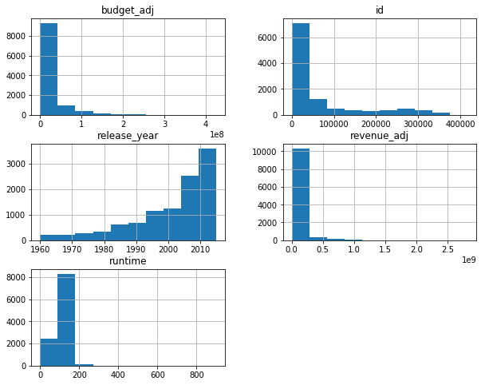

```python
df.hist(figsize=(10,8));
```

```python
# drop rows with a runtime of 0, because that is illogical
df.drop(df[df.runtime == 0].index, inplace=True)

df.info()
```

```
<class 'pandas.core.frame.DataFrame'>
Int64Index: 10835 entries, 0 to 10865
Data columns (total 7 columns):
id                      10835 non-null int64
runtime                 10835 non-null int64
production_companies    9823 non-null object
release_date            10835 non-null object
release_year            10835 non-null int64
budget_adj              10835 non-null float64
revenue_adj             10835 non-null float64
dtypes: float64(2), int64(3), object(2)
memory usage: 677.2+ KB
```

```python
df[(df.budget_adj == 0) | (df.revenue_adj == 0)]
#drop columns that are missing either adjusted budget or adjusted
#revenue because it is illogical to have one and not the other
df.drop(df[(df.budget_adj == 0) | (df.revenue_adj == 0)].index, inplace=True)

df.info()
```

```
<class 'pandas.core.frame.DataFrame'>
Int64Index: 3855 entries, 0 to 10848
Data columns (total 7 columns):
id                      3855 non-null int64
runtime                 3855 non-null int64
production_companies    3809 non-null object
release_date            3855 non-null object
release_year            3855 non-null int64
budget_adj              3855 non-null float64
revenue_adj             3855 non-null float64
dtypes: float64(2), int64(3), object(2)
memory usage: 240.9+ KB
```

```python
#Delete duplicated rows (Only 1 row)
df=df.drop_duplicates()

df.info()
```

```
<class 'pandas.core.frame.DataFrame'>
Int64Index: 3854 entries, 0 to 10848
Data columns (total 7 columns):
id                      3854 non-null int64
runtime                 3854 non-null int64
production_companies    3808 non-null object
release_date            3854 non-null object
release_year            3854 non-null int64
budget_adj              3854 non-null float64
revenue_adj             3854 non-null float64
dtypes: float64(2), int64(3), object(2)
memory usage: 240.9+ KB
```

```python
#Create profit column (Revenue - Budget)
df.insert(7,"profits",df["revenue_adj"]-df["budget_adj"])
```

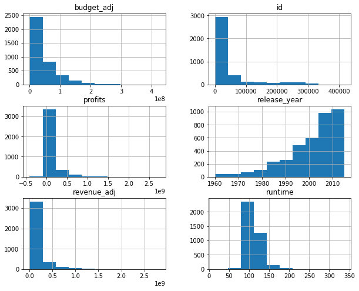

```python
df.hist(figsize=(10,8));
```

```python
df[df.production_companies.isnull()]
#Dropping null values in production companies
df.dropna(inplace=True)

df.info()
```

```
<class 'pandas.core.frame.DataFrame'>
Int64Index: 3808 entries, 0 to 10848
Data columns (total 8 columns):
id                      3808 non-null int64
runtime                 3808 non-null int64
production_companies    3808 non-null object
release_date            3808 non-null object
release_year            3808 non-null int64
budget_adj              3808 non-null float64
revenue_adj             3808 non-null float64
profits                 3808 non-null float64
dtypes: float64(3), int64(3), object(2)
memory usage: 267.8+ KB
```

```python
df.head()
```

|  | id | runtime | production_companies | release_date | release_year | budget_adj | revenue_adj | profits |
| --- | --- | --- | --- | --- | --- | --- | --- | --- |
| 0 | 135397 | 124 | Universal Studios\|Amblin Entertainment\|Legenda... | 6/9/15 | 2015 | 1.379999e+08 | 1.392446e+09 | 1.254446e+09 |
| 1 | 76341 | 120 | Village Roadshow Pictures\|Kennedy Miller Produ... | 5/13/15 | 2015 | 1.379999e+08 | 3.481613e+08 | 2.101614e+08 |
| 2 | 262500 | 119 | Summit Entertainment\|Mandeville Films\|Red Wago... | 3/18/15 | 2015 | 1.012000e+08 | 2.716190e+08 | 1.704191e+08 |
| 3 | 140607 | 136 | Lucasfilm\|Truenorth Productions\|Bad Robot | 12/15/15 | 2015 | 1.839999e+08 | 1.902723e+09 | 1.718723e+09 |
| 4 | 168259 | 137 | Universal Pictures\|Original Film\|Media Rights ... | 4/1/15 | 2015 | 1.747999e+08 | 1.385749e+09 | 1.210949e+09 |

## Exploratory Data Analysis

After Cleaning the data I will show the differences noticed from the summary given above.

```python
df.describe()
```

|  | id | runtime | release_year | budget_adj | revenue_adj | profits |
| --- | --- | --- | --- | --- | --- | --- |
| count | 3808.000000 | 3808.000000 | 3808.000000 | 3.808000e+03 | 3.808000e+03 | 3.808000e+03 |
| mean | 40024.657826 | 109.362395 | 2001.232668 | 4.468660e+07 | 1.386096e+08 | 9.392298e+07 |
| std | 67561.455863 | 19.855757 | 11.326075 | 4.488486e+07 | 2.169449e+08 | 1.949739e+08 |
| min | 5.000000 | 15.000000 | 1960.000000 | 9.693980e-01 | 2.370705e+00 | -4.139124e+08 |
| 25% | 5947.500000 | 96.000000 | 1995.000000 | 1.352552e+07 | 1.916596e+07 | -1.420694e+06 |
| 50% | 11257.500000 | 106.000000 | 2004.000000 | 3.038360e+07 | 6.280952e+07 | 2.836532e+07 |
| 75% | 38576.000000 | 119.000000 | 2010.000000 | 6.082162e+07 | 1.655712e+08 | 1.089595e+08 |
| max | 417859.000000 | 338.000000 | 2015.000000 | 4.250000e+08 | 2.827124e+09 | 2.750137e+09 |

Post-data-cleaning **describe** shows us some interesting information information after cleaning the data. We can first notice that we went from over 10,000 rows to 3,808 because of missing data. But I have removed rows with missing data because to normalize the data and accurately represent the data given. The biggest chunk of data removed was due to missing budget and/or revenue values. I removed these because it skewed the data and wouldn't accurately show us relationships if only one of the two, or both, were missing.

*Adjusted Budget*

- The **Least** expensive film cost **1** dollars
- The **Most** expensive film cost **425,000,000** dollars
- The **Average** budget of a film is **44,686,600** dollars

*Adjusted Revenue*

- The **Least** money a film has brought in is **2** dollars
- The **Most** money a film has brought in is **2,827,124,000** dollars
- The **Average** money films bring in is **138,609,600** dollars

*Runtime*

- The **Shortest** film made is **15** minutes
- The **Longest** film made is **338** minutes
- The **Average** length of a film is **109** minutes

### 1. Which decade spent/made the most money?

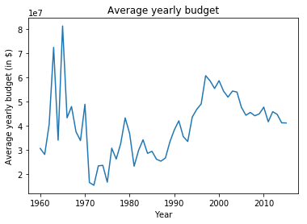

```python
#Calculated average yearly budget
plt.plot(df.groupby("release_year").mean().budget_adj);
plt.xlabel("Year");
plt.ylabel("Average yearly budget (in $)");
plt.title("Average yearly budget")
plt.show()
```

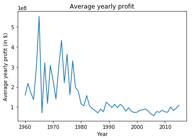

```python
#Calculate average yearly profit
plt.plot(df.groupby("release_year").mean().profits);
plt.xlabel("Year");
plt.ylabel("Average yearly profit (in $)");
plt.title("Average yearly profit")
plt.show()
```

**Analysis** It looks like spending on movies really peaked in 1960's, but those years also had the most profits. It was however also very unstable with wildly fluctuating data. Starting the 1990's profits stabilized, but the budgets started to rise again.